# Test a Perceptual Phenomenon - Stroop Effect by Steve T

### Abstract

In psychology, the Stroop effect is a demonstration of interference in the reaction time of a task. When the name of a color (e.g., “blue”, “green”, or “red”) is printed in a color that is not denoted by the name (e.g., the word “red” printed in blue ink instead of red ink), naming the color of the word takes longer and is more prone to errors than when the color of the ink matches the name of the color. The effect is named after John Ridley Stroop, who first published the effect in English in 1935.

### Dataset

In a Stroop task, participants are presented with a list of words, with each word displayed in a color of ink. The participant???s task is to say out loud the color of the ink in which the word is printed. The task has two conditions: a congruent words condition, and an incongruent words condition. In the congruent words condition, the words being displayed are color words whose names match the colors in which they are printed: for example RED, BLUE. In the incongruent words condition, the words displayed are color words whose names do not match the colors in which they are printed: for example PURPLE, ORANGE. In each case, we measure the time it takes to name the ink colors in equally-sized lists. Each participant will go through and record a time from each condition. Each row of the dataset contains the performance for one participant, with the first number their results on the congruent task and the second number their performance on the incongruent task. There are a total of 24 observation per category.

```
## 'data.frame':    24 obs. of  2 variables:
##  $ Congruent  : num  12.08 16.79 9.56 8.63 14.67 ...
##  $ Incongruent: num  19.3 18.7 21.2 15.7 22.8 ...
```

# Questions For Investigation Section

### 1. What is our independent variable? What is our dependent variable?

- Independent variable - the congruency of the word condition
- Dependent variable - the response time to name the ink color in equally-sized list.

### 2. What is an appropriate set of hypotheses for this task? What kind of statistical test do you expect to perform?

$\overline{u}_\Delta$ : The mean for the paired difference.

$H_0:\overline{u}_\Delta = 0$ - The time taken for the participant to name the ink color for both congruent and incongruent condition should be the same. $H_A:\overline{u}_\Delta \neq 0$ - The time taken for the participant to name the ink color for both congruent and incongruent condition is different.

As we do not know the population standard deviation of this test plus the sample size is smaller than 30, we’re looking at conducting a t-test here. So because we’re interested to see if the interference due to the incongruent word condition actually caused any difference in the response time for the participant, and the same participant is administered to both of the congruent and incongruent word conditions, this introduces a paired t-test because the two samples are related. Finally, since we’re checking for difference in the response time for the participant, the mean response time can indeed be smaller or larger thus this is a two tail t-test.

### 3. Report some descriptive statistics regarding this dataset.

### 4. Provide one or two visualizations that show the distribution of the sample data.

```
##    Min. 1st Qu.  Median    Mean 3rd Qu.    Max.
##    8.63   11.90   14.36   14.05   16.20   22.33
```

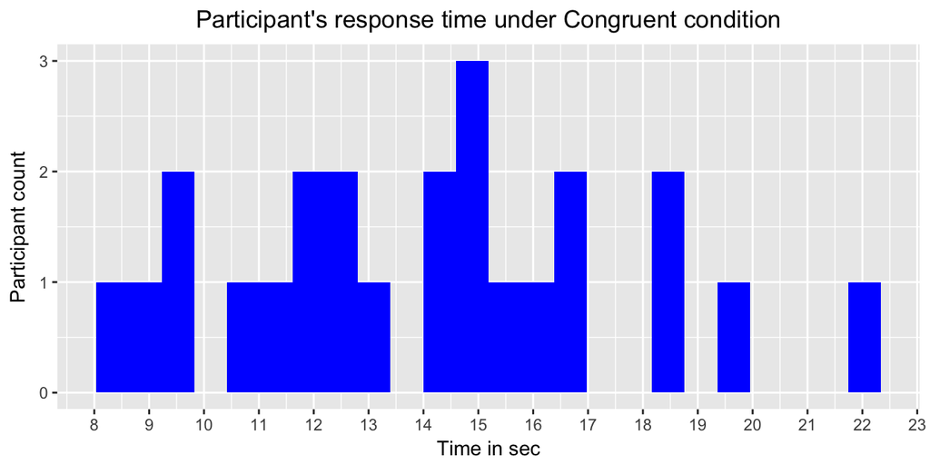

For the congruent histogram, we can see there are quite a few of gaps between the value, and overall the distribution does resemble a normal distribution. There’s no obvious outlier in the plot. Let’s check on the incongruent plot next. The median and the mean is pretty near with the median value of 14.36 and mean value of 14.05

```
##    Min. 1st Qu.  Median    Mean 3rd Qu.    Max.
##   15.69   18.72   21.02   22.02   24.05   35.26
```

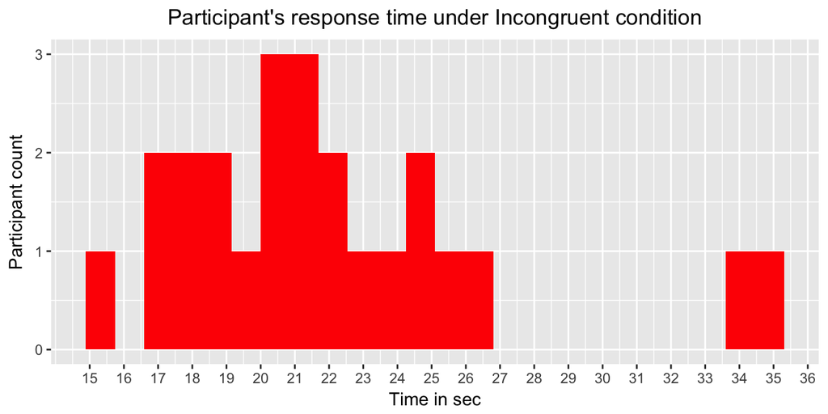

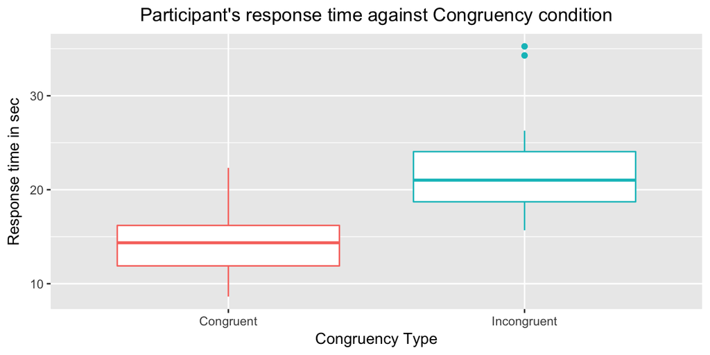

Contrasting the two box plot, we can see that the median for incongruent is much higher than the congruent one, and the whole of IQR box for the incongruent never touches the one for the congruent at all. Using the boxplot, we can also see that for the Incongruent value are actually affected by two outlier points. So we know that the median for the two groups are different but is it significantly different? Let’s confirm this on the next section via the t-test.

### 5. Now, perform the statistical test and report your results. What is your confidence level and your critical statistic value? Do you reject the null hypothesis or fail to reject it? Come to a conclusion in terms of the experiment task. Did the results match up with your expectations?

```
## [1] "Comparing the congruent response time to the incongruent response time:"
```

```
## Mean of the difference: -7.965
```

```
## Std Dev of the difference: 4.865
```

```
## Count of the mean dif: 24
```

```
## Degree of freedom of the mean dif: 23
```

```
## Std error of the mean dif: 0.993064
```

```
## 95% confidence level t-critical value lower bound: -2.069  and upper bound: 2.069
```

```
## t-critical value of the mean dif: -8.021
```

```
## p-value value of the mean dif: 4.100426e-08
```

We use the default confidence level at 95% Based on the t-critical value, -8.021 was way lower than the lower bound of the t-critical confidence level,-2.069, so we can reject the null.

```
##
##  Paired t-test
##
## data:  sdf$Congruent and sdf$Incongruent
## t = -8.0207, df = 23, p-value = 4.103e-08
## alternative hypothesis: true difference in means is not equal to 0
## 95 percent confidence interval:
##  -10.019028  -5.910555
## sample estimates:
## mean of the differences
##               -7.964792
```

We ran the t-test function to verify that the t-statistics value and the p-value that was calculated is correct. Based on these values, the stroop effect clearly caused a significant delay in the response time of the participants when the words and colors are incongruent. I would have anticipated a delay in the response time because we have seen that there’s a large gap in the median values between the two data set and intuitively it makes sense since we’re splitting our mental resources to do two tasks reading the words and color vs reading just the words and assuming that the colors will match the word.

### 6. What do you think is responsible for the effects observed? Can you think of an alternative or similar task that would result in a similar effect? Some research about the problem will be helpful for thinking about these two questions!

Based on the experiment, J. Ridley Stroop developed two experimental theories to explain this occurence: The first theory was called - Speed of Processing Theory: He showed that the Interference occurs because, people are able to read words much quicker and to name the colour of the word is much more complex. The second theory was called - Selective Attention Theory: Interference occurs because; naming the actual colour of the words requires much more attention than reading the words. So in other words, we’re more adept at reading words than colors because we’re very used to doing that but unless our job or daily task revolves around naming colors, otherwise we would be slower in naming color versus just reading the name of the color. Thus in the situation of the incongruent condition, we would require more time to read the color and try to ignore the printed word. There are also other conflict tasks such as the Stroop effect, such as the Eriksen Flanker task, in which researchers try to determine the response time of the participants were a result of the proximity of the noise to the target or the similarity of the noise to the target. Basically the researchers wanted to know if the participants would get distracted by other elements in the search task if the other elements were closer to the target as compared to the other elements being very similar to the target. In another lesser known interference test, the Simon effect refers to the finding that reaction times are usually faster, and reactions are usually more accurate, when the stimulus occurs in the same relative location as the response, even if the stimulus location is irrelevant to the task. Simon’s original explanation for the effect was that there is an innate tendency to respond toward the source of stimulation. All three tasks demonstrated that the response time was shortest when the conditions are congruent.

# References

1. data set options - https://drive.google.com/file/d/0B9Yf01UaIbUgQXpYb2NhZ29yX1U/view
2. rubric - https://review.udacity.com/#!/rubrics/71/view
3. instruction - https://docs.google.com/document/d/1-OkpZLjG_kX9J6LIQ5IltsqMzVWjh36QpnP2RYpVdPU/pub?embedded=True
4. latex format - http://web.ift.uib.no/Teori/KURS/WRK/TeX/symALL.html
5. t-table reference - https://s3.amazonaws.com/udacity-hosted-downloads/t-table.jpg
6. What is Stroop effect - https://d2l.deakin.edu.au/d2l/eP/presentations/presentation_preview_popup.d2l?presId=67655
7. Flanker task - https://en.wikipedia.org/wiki/Eriksen_flanker_task
8. Stroop effect and Flanker task - https://stroopeffectandflankertask.weebly.com/the-eriksen-flanker-task.html
9. Simon effect - https://en.wikipedia.org/wiki/Simon_effect